# ANALISE DO DATASET WINE QUALITY

### **“Conceitos Estatísticos para IA”**

#### *Prof. Adelaide Alves de Oliveira*

- TURMA: FIAP-06IA
  - EDUARDO MORARES
  - EDUARDO SIQUEIRA DE LIMA
  - GABRIEL SHIKAMA
  - RICARDO KALIMANIS

Inicicalmente vamos instalar os pacotes, caso seja necessário, que serão usados no decorrer da análise

```r
#ignorando alertas para não poluir a exibição do markdwon
options(warn =-1)

#lista de pacotes que iremos utilizar no projeto
Pacotes_Necessarios <- c("ggplot2","readr","dplyr", "corrgram","corrplot", "plotly","skimr","gridExtra","GGally","ggpubr")

#com base nos pacotes instalados crio uma variavel somente com os pacotes que não temos ainda para realizar a instalação
#dos pacotes que de fato não possuimos
PacotesNovos <- Pacotes_Necessarios[!(Pacotes_Necessarios %in% installed.packages()[,"Package"])]
if(length(PacotesNovos)){ install.packages(PacotesNovos)} else {print("Todos os Pacotes Estão Instalados")}
```

```
[1] "Todos os Pacotes Estão Instalados"
```

Carregando todas as as Bibliotecas mencionadas no passo anterior

```r
lapply(Pacotes_Necessarios, require, character.only = TRUE)
```

Importando os Datasets de Wines Quality.

#### Lista DE - PARA das colunas

| Nome no Arquivo | Nome Traduzido |
| --- | --- |
| ID | ID (que não sera utilizado) |
| fixed acidity | acidez_fixa |
| volatile acidity | acidez_volatil |
| citric acid | acido_citrico |
| residual sugar | acucar_residual |
| chlorides | cloretos |
| free sulfur dioxide | fsd |
| total sulfur dioxide | tsd |
| density | densidade |
| pH | PH |
| sulphates | sulfatos |
| alcohol | grau_alcolico |
| quality | qualidade |
| Vinho | Tipo |

```r
#Criando uma variável nome_colunas que receberá os nomes das colunas que normalizaremos a fim de facilitar o resto da análise
nome_colunas <- c("id","acidez_fixa","acidez_volatil","acido_citrico","acucar_residual","cloretos", "fsd", "tsd","densidade","PH", "sulfatos","grau_alcolico","qualidade","tipo")

#uso da biblioteca readr é para obter uma performance de carga melhor que a lib padrão do R
#e escolhemos o read_csv2 justamente pelo fato do arquivo estar separado por ; ao invés de ,
#o separador decimal também não é o . que é convencional e este comando ja os converte facilmente
#skip = 1 para ignorar o cabecalho que mudamos para melhor entendimento
vinhos <- read_csv2("./DataSets/BaseWine_Red_e_White.csv" ,col_names = nome_colunas, skip = 1)
```

```r
#converte tipo paara fator
vinhos$tipo <- factor(vinhos$tipo, ordered = T)

#Criando uma coluna de Ranking para dizer o quão bom é o vinho
vinhos$rating <- factor(ifelse(vinhos$qualidade <= 5, 'Ruim', ifelse(vinhos$qualidade <= 7, 'Bom', 'Excelente')))
```

Exibindo os dados das dimensões, sumário, estrutura e as primeiras linhas do DataFrame Vinhos

```r
attach(vinhos)
```

```r
skim(vinhos[, names(vinhos) != "id"] )
```

```
Skim summary statistics
 n obs: 6497
 n variables: 14

-- Variable type:factor --------------------------------------------------------
 variable missing complete    n n_unique                            top_counts ordered
   rating       0     6497 6497        3 Bom: 3915, Rui: 2384, Exc: 198, NA: 0   FALSE
     tipo       0     6497 6497        2           WHI: 4898, RED: 1599, NA: 0    TRUE

-- Variable type:numeric -------------------------------------------------------
        variable missing complete    n    mean     sd    p0    p25     p50     p75   p100     hist
     acidez_fixa       0     6497 6497   7.22   1.3   3.8    6.4     7       7.7    15.9  ▁▇▇▂▁▁▁▁
  acidez_volatil       0     6497 6497   0.34   0.16  0.08   0.23    0.29    0.4     1.58 ▇▇▂▁▁▁▁▁
   acido_citrico       0     6497 6497   0.32   0.15  0      0.25    0.31    0.39    1.66 ▂▇▂▁▁▁▁▁
 acucar_residual       0     6497 6497   5.44   4.73  0.6    1.8     3       8.1    45.8  ▇▂▂▁▁▁▁▁
        cloretos       0     6497 6497   0.056  0.035 0.009  0.038   0.047   0.065   0.61 ▇▁▁▁▁▁▁▁
       densidade       0     6497 6497   0.99   0.003 0.99   0.99    0.99    1       1.01 ▂▇▇▅▁▁▁▁
             fsd       0     6497 6497  30.53  17.75  1     17      29      41     289    ▇▃▁▁▁▁▁▁
   grau_alcolico       0     6497 6497  10.49   1.22  0.96   9.5    10.3    11.3    14.9  ▁▁▁▁▆▇▃▁
              PH       0     6497 6497   3.22   0.16  2.72   3.11    3.21    3.32    4.01 ▁▃▇▇▃▁▁▁
       qualidade       0     6497 6497   5.82   0.87  3      5       6       6       9    ▁▁▆▇▁▃▁▁
        sulfatos       0     6497 6497   0.53   0.15  0.22   0.43    0.51    0.6     2    ▅▇▂▁▁▁▁▁
             tsd       0     6497 6497 115.74  56.52  6     77     118     156     440    ▅▆▇▃▁▁▁▁
```

Distribuição da Qualidade do Vinho por tipo de vinho e classificação

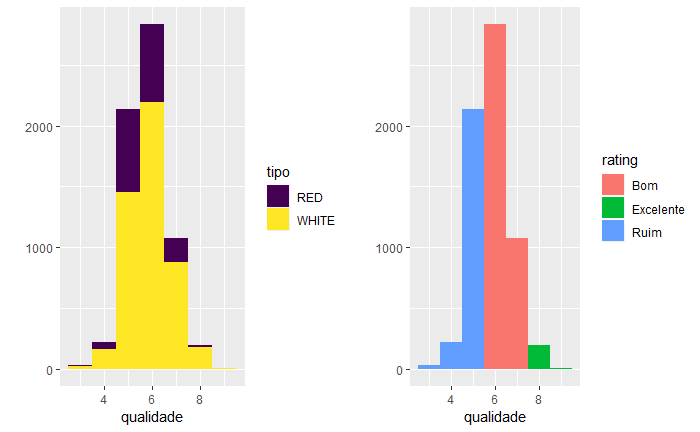

```r
grafico_1 <- qplot(qualidade, data = vinhos, fill = tipo, binwidth = 1)
grafico_2 <- qplot(qualidade, data = vinhos, fill = rating, binwidth = 1)

grid.arrange(grafico_1, grafico_2, ncol=2)
```

Observa-se que as qualidades dos vinhos se encontram em uma distribuição normal. Sabe-se que a maior concentração de notas está na regão entre nota 4 e 8. Entretando, antes de aprofundarmos em qualquer análise que envolvem os dados é necessário pontuar se há existencia de outliers e remove-los caso existam

O comando aplicado para todos atributos abaixo exibição dos box-plot abaixo foi:

> *boxplot(Column_Name, col=“slategray2”, pch=19)*  
> *mtext(“Titulo” , cex=0.8, side=1, line=2)*

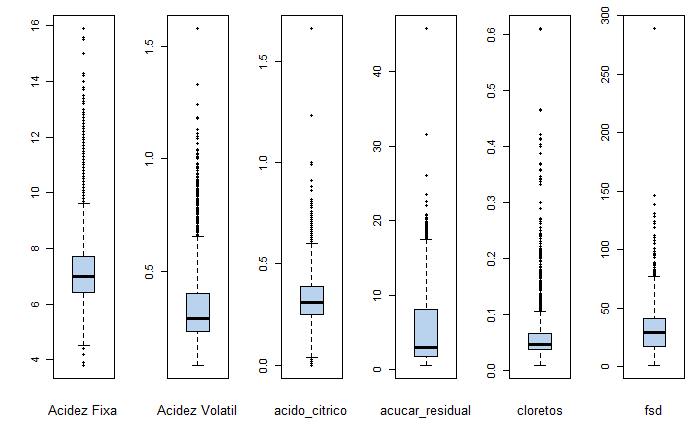

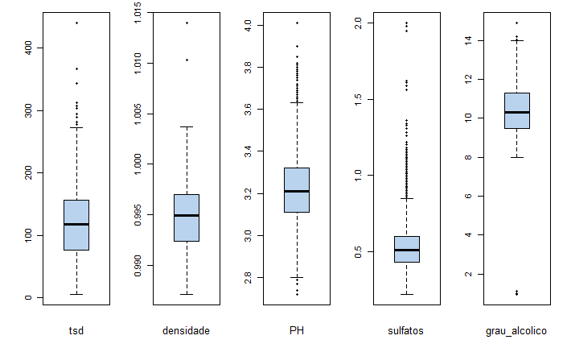

### **Outliers**

Nota se que quase todas as variáveis possuem outliers e para uma melhor acurácia no modelo iremos removê-las da análise. O Metodo mais indicado para remoção dos outliers é amplitude interquartil (IQR - InterQuantile Range) onde: *IQR = Q3(quartil 3) - Q1(quartil 1) Com o IQR calculado é necessário definir o limite inferior e superior que é dado pela seguinte formula:

$$Lim_{Sup} = \bar{X} + 1,5 * IQR$$

$$Lim_{Inf} = \bar{X} - 1,5 * IQR$$

[figure not shown]

De modo que a remoção dos outliers fez com que a distribuição dos dados ficasse mais homogênea como demonstro nos histrogramas a seguir

```r
  #comparando os resultados
  par(mfrow=c(1,2), oma = c(1,1,0,0) + 0.1,  mar = c(3,3,1,1) + 0.1)
    hist(acidez_fixa, col="slategray2", main = "")
    mtext("Antes" , cex=0.8, side=1, line=2)
```

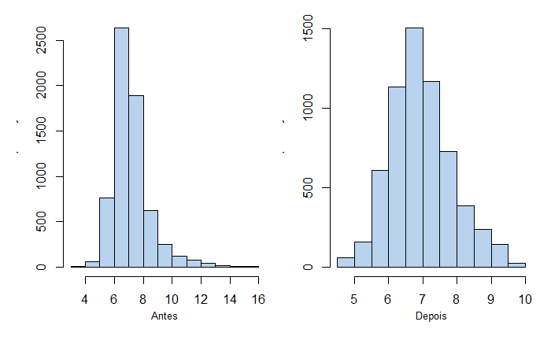

```r
    hist(Vinhos_Normalizado$acidez_fixa, col="slategray2", main = "")
    mtext("Depois" , cex=0.8, side=1, line=2)
```

```r
vinhos_final$acidez_fixa <- remove_outliers(acidez_fixa, T)
```

Examinando os dados pos limpeza dos outliers

```r
par(mfrow=c(1,2), oma = c(1,1,0,0) + 0.1,  mar = c(3,3,1,1) + 0.1)
  boxplot(acidez_volatil, col="slategray2", pch=19)
  mtext("Acidez Volatil", cex=0.8, side=1, line=2)
  boxplot(teste, col="slategray2", pch=19)
  mtext("teste", cex=0.8, side=1, line=2)
```

[output not shown]